# Lab 5

k-nearest neighbor

Assigned 5/6/20, Due 5/13/19

The goal of this lab is to apply and tune *K*-nearest neighbor models, and explore non-regular grids.

For this lab, we are going to use the `Ames` housing data - the `{iris}` of machine learning data sets. The `Ames` data describes “the sale of individual residential property in Ames, Iowa from 2006 to 2010” ([De Cock, 2011](http://jse.amstat.org/v19n3/decock.pdf)). The raw data set “contains 2930 observations and a large number of explanatory variables (23 nominal, 23 ordinal, 14 discrete, and 20 continuous) involved in assessing home values.”

The `Ames` raw data comes from the `{AmesHousing}` package. Explore the variables with `?ames_raw`. We will apply the `make_ames()` function to use the processed version of the data, where all factors are unordered, column names are Snake_Case, some columns were removed, some missing values were recoded, many factor levels were changed to more understandable, and longitude and latitude are included. See `?make_ames` for more infomormation.

Note that the goal of this lab is **not** to make the most accurate predictions, so please do not get too bogged down into the data features. Some useful features are: **Neighborhood**, **Year_Sold**, **Longitude**, **Latitude**, **Gr_Liv_Area**, **Bedroom_AbvGr**, **Full_Bath**, **Half_Bath**.

We will be predicting **Sale_Price.**

### 1. Data

Run the code chunk below to load the packages and the processed `ames` data that you will be using. Note that you may need to first install `{AmesHousing}` if you have never done so.

```r
library(tidyverse)
library(tidymodels)
library(AmesHousing)
library(skimr)
library(doParallel)
library(tictoc)
library(kknn)
#Make the processed ames data
ames <- make_ames()

ames_short <- ames %>%
  select(c(Neighborhood, Year_Sold, Longitude, Latitude, Gr_Liv_Area, Bedroom_AbvGr, Full_Bath, Half_Bath, Lot_Area, Year_Built, Exter_Qual, Sale_Price, Fence, Garage_Area))
```

### 2. Get to know the data

Briefly explore the `ames` data to get a (small) understanding of the data set. How you do this is entirely up to you. You could use look at the correlations between the features and `Sale_Price`, use the `{skimr}` package to get an initial look at the data, make some quick plots using `{ggplot2}`, or use your usual routine for initial data exploration. Try to do this in about 15 minutes.

Data summary

| Name | ames_short |
| --- | --- |
| Number of rows | 2930 |
| Number of columns | 14 |
| _______________________ |  |
| Column type frequency: |  |
| factor | 3 |
| numeric | 11 |
| ________________________ |  |
| Group variables | None |

**Variable type: factor**

| skim_variable | n_missing | complete_rate | ordered | n_unique | top_counts |
| --- | --- | --- | --- | --- | --- |
| Neighborhood | 0 | 1 | FALSE | 28 | Nor: 443, Col: 267, Old: 239, Edw: 194 |
| Exter_Qual | 0 | 1 | FALSE | 4 | Typ: 1799, Goo: 989, Exc: 107, Fai: 35 |
| Fence | 0 | 1 | FALSE | 5 | No_: 2358, Min: 330, Goo: 118, Goo: 112 |

**Variable type: numeric**

| skim_variable | n_missing | complete_rate | mean | sd | p0 | p25 | p50 | p75 | p100 | hist |
| --- | --- | --- | --- | --- | --- | --- | --- | --- | --- | --- |
| Year_Sold | 0 | 1 | 2007.79 | 1.32 | 2006.00 | 2007.00 | 2008.00 | 2009.00 | 2010.00 | ▇▇▇▇▃ |
| Longitude | 0 | 1 | -93.64 | 0.03 | -93.69 | -93.66 | -93.64 | -93.62 | -93.58 | ▅▅▇▆▁ |
| Latitude | 0 | 1 | 42.03 | 0.02 | 41.99 | 42.02 | 42.03 | 42.05 | 42.06 | ▂▂▇▇▇ |
| Gr_Liv_Area | 0 | 1 | 1499.69 | 505.51 | 334.00 | 1126.00 | 1442.00 | 1742.75 | 5642.00 | ▇▇▁▁▁ |
| Bedroom_AbvGr | 0 | 1 | 2.85 | 0.83 | 0.00 | 2.00 | 3.00 | 3.00 | 8.00 | ▁▇▂▁▁ |
| Full_Bath | 0 | 1 | 1.57 | 0.55 | 0.00 | 1.00 | 2.00 | 2.00 | 4.00 | ▁▇▇▁▁ |
| Half_Bath | 0 | 1 | 0.38 | 0.50 | 0.00 | 0.00 | 0.00 | 1.00 | 2.00 | ▇▁▅▁▁ |
| Lot_Area | 0 | 1 | 10147.92 | 7880.02 | 1300.00 | 7440.25 | 9436.50 | 11555.25 | 215245.00 | ▇▁▁▁▁ |
| Year_Built | 0 | 1 | 1971.36 | 30.25 | 1872.00 | 1954.00 | 1973.00 | 2001.00 | 2010.00 | ▁▂▃▆▇ |
| Sale_Price | 0 | 1 | 180796.06 | 79886.69 | 12789.00 | 129500.00 | 160000.00 | 213500.00 | 755000.00 | ▇▇▁▁▁ |
| Garage_Area | 0 | 1 | 472.66 | 215.19 | 0.00 | 320.00 | 480.00 | 576.00 | 1488.00 | ▃▇▃▁▁ |

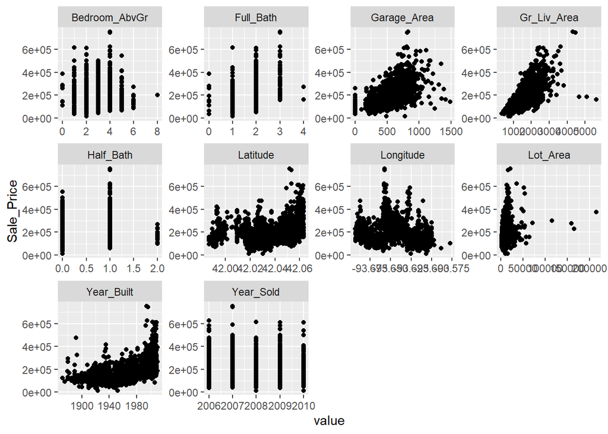

### 3. Split and Resample

Split the `ames` data from above into a training and test set (use seed `210`). Use one of the methods we have learned to resample the traning set. It is up to you if you want/need to use stratified resampling.

### 4. Preprocess

Create a `recipe` to prepare your data for a *K*NN model.

### 5. Set a *K*NN model

Create a `{parsnip}` model for a *K*NN model and allow for the `neighbors` and `weight_func` hyperparameters to be tuned.

```
## K-Nearest Neighbor Model Specification (regression)
##
## Computational engine: kknn
##
## Model fit template:
## kknn::train.kknn(formula = missing_arg(), data = missing_arg(),
##     ks = 5)
```

### 6. Create non-regular grid

Create a non-regular, space-filling design grid using `grid_max_entropy` and 50 parameter values. Tune the range of `neighbors` hyperparameter for `c(1:20)` and any 5 levels of the `weight_func` hyperparameter. Produce a `ggplot` to show a graphical representation of your non-regular grid.

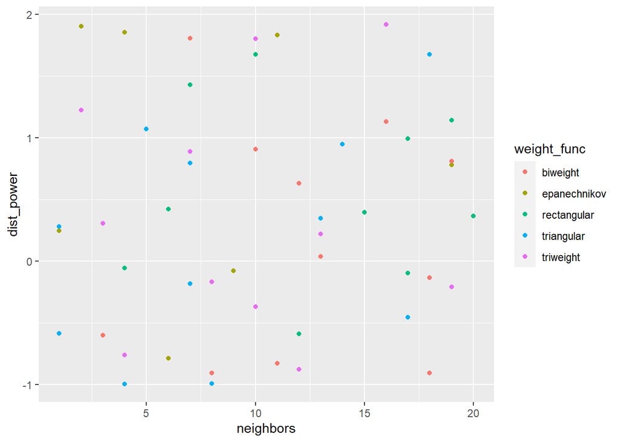

### 7. Fit your tuned models

Fit your tuned *K*NN model to your `resamples`, using your specified `recipe` and non-regular `grid`. Show the top 5 tuned parameter models with the best `rmse` estimates.

```
## [1] 8
```

```
## 362.12 sec elapsed
```

```
## # A tibble: 5 x 8
##   neighbors weight_func dist_power .metric .estimator   mean     n std_err
##       <int> <chr>            <dbl> <chr>   <chr>       <dbl> <int>   <dbl>
## 1        12 biweight         0.632 rmse    standard   35687.    10   1179.
## 2        10 biweight         0.905 rmse    standard   35846.    10   1133.
## 3         7 triangular       0.793 rmse    standard   36049.    10   1185.
## 4        19 biweight         0.809 rmse    standard   36067.    10   1337.
## 5        14 triangular       0.948 rmse    standard   36354.    10   1398.
```

### 8. Recreate `autoplot()`

Run `autoplot()` on your fitted tuned model object. Then reproduce that `autoplot` figure using `ggplot2`.

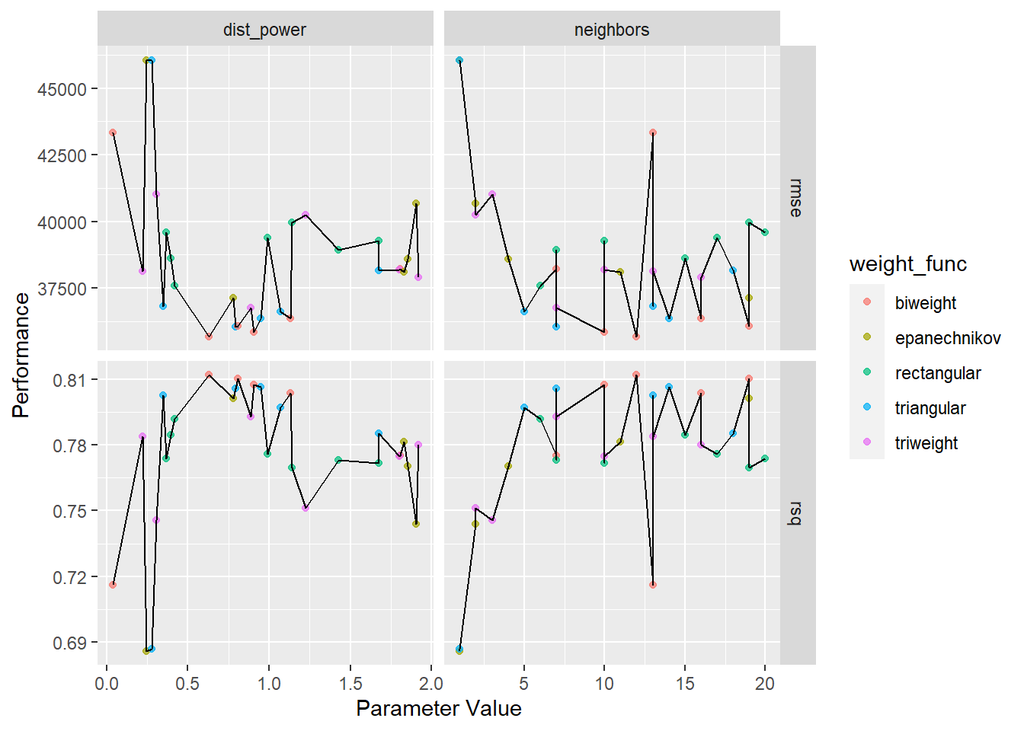

```
## # A tibble: 6 x 5
## # Groups:   weight_func [2]
##   weight_func  .metric  means tunes      `Parameter Value`
##   <chr>        <chr>    <dbl> <chr>                  <dbl>
## 1 epanechnikov rmse    46062. neighbors              1
## 2 epanechnikov rmse    46062. dist_power             0.246
## 3 triangular   rmse    46042. neighbors              1
## 4 triangular   rmse    46042. dist_power             0.279
## 5 epanechnikov rmse    40669. neighbors              2
## 6 epanechnikov rmse    40669. dist_power             1.90
```

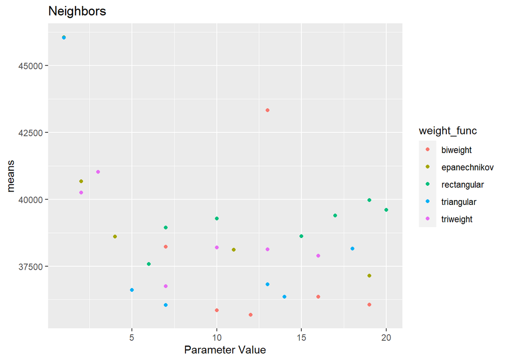

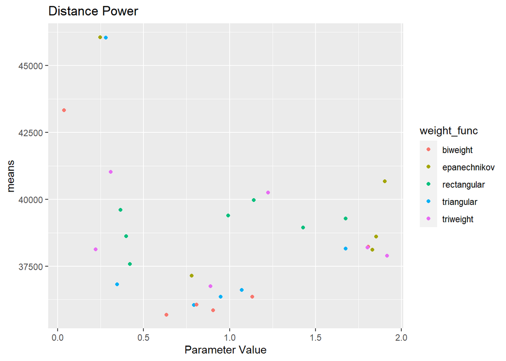

### 9. Final fit

Conduct your final fit by using: * `select_best` to select your best tuned model * `finalize_model` to finalize your model using your best tuned model * `finalize_recipe` to finalize your recipe using your best tuned model * `last_fit` to run your last fit with your `finalized_model` and `finalized_recipe`on your initial data split * `collect_metrics` from your final results

```
## # A tibble: 2 x 3
##   .metric .estimator .estimate
##   <chr>   <chr>          <dbl>
## 1 rmse    standard   30150.
## 2 rsq     standard       0.852
```